# VIS 2128 - Assignment 3

Group 14 - Aeshna Prasad, Claire Tham, Cam McCutchen

9/23/2021

**Introduction** We chose to analyze San Francisco [SF] for this week’s assignment. More specifically, we wanted to understand which neighborhoods supported the city’s green and sustainable goals most and aligned with that. In order to do that we chose the following datasets:

Points: A) Urban Trees (this is a data set that excludes trees in parks specifically) B) Bike Stations (this is derived from the Bike Network data set) B2) Green Roofs (this is an extra layer we wanted to use)

Polygons: C) Neighborhoods D) Parks

Potential areas of future research could include adding a layer of racial data in addition to other demographic data to lead to deeper insights.

**Mapping All the Data**

```r
#Loading Data

nbhoods <- st_read("https://data.sfgov.org/api/geospatial/pty2-tcw4?method=export&format=GeoJSON" , quiet = TRUE)

bikenetwork <- st_read("https://data.sfgov.org/api/geospatial/msjm-67c8?method=export&format=GeoJSON", quiet = TRUE)

greenroofs <- st_read("https://data.sfgov.org/api/geospatial/x83m-rafs?method=export&format=GeoJSON" , quiet = TRUE)

parks <- st_read("https://data.sfgov.org/api/geospatial/42rw-e7xk?method=export&format=GeoJSON", quiet = TRUE)

trees <- read.csv(file = 'Street_Tree_List.csv')
```

```r
#Transform Coordinate Plane for KML dataset

ca_state_plane <- "+proj=lcc +lat_1=40 +lat_2=41.66666666666666 +lat_0=39.33333333333334 +lon_0=-122 +x_0=2000000 +y_0=500000.0000000002 +ellps=GRS80 +datum=NAD83 +to_meter=0.3048006096012192 +no_defs "

nbhoods <- nbhoods %>%
  st_transform(ca_state_plane)

bikenetwork <- bikenetwork %>%
  st_transform(ca_state_plane)

greenroofs <- greenroofs %>%
  st_transform(ca_state_plane)

parks <- parks %>%
  st_transform(ca_state_plane) %>%
filter(map_park_n != "Camp Mather")
```

```r
#Converting Coordinate System for CSV dataset

trees_csv <- read.csv(file = "https://data.sfgov.org/api/views/tkzw-k3nq/rows.csv?accessType=DOWNLOAD")

trees_csv <- trees_csv %>%
  drop_na(c("Latitude", "Longitude"))

trees_sf <- st_as_sf(trees_csv, coords = c("Longitude", "Latitude"),
                     crs = "+proj=longlat +ellps=WGS84 +datum=WGS84 +no_defs") %>%

  st_transform(ca_state_plane)
```

```r
#Sub-setting

trees_inside <- trees_sf[nbhoods,]
parks_inside <- parks[nbhoods,]
```

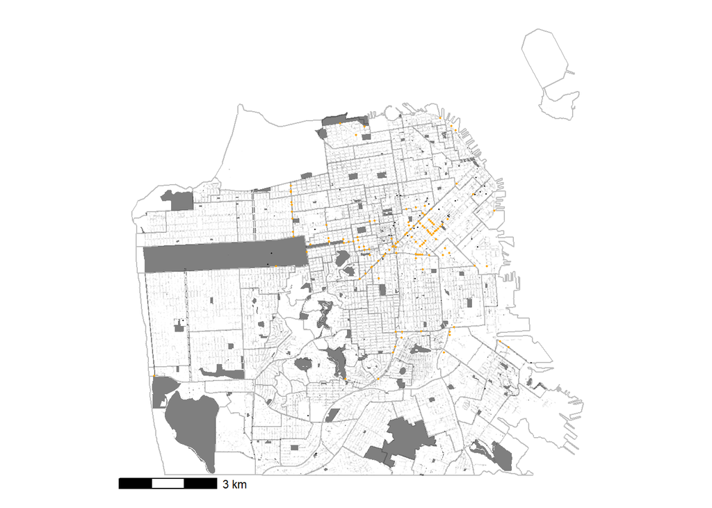

```r
#Plotting All Data

ggplot(nbhoods) +
  geom_sf(fill = NA, color = "gray") +
  geom_sf(data = trees_inside , size = 0.01, alpha = 0.01) +
  geom_sf(data = greenroofs, size = 0.2) +
  geom_sf(data= parks_inside, fill = "black", color = NA, alpha = 0.5) +
  geom_sf(data= bikenetwork, fill = NA, color = "orange", size = 0.3) +
  theme_map() +
  annotation_scale()
```

**Map 1:** **(5) The number and proportion of A points within C polygons**

How many of the urban tress [A] are within each SF neighborhood [C]?

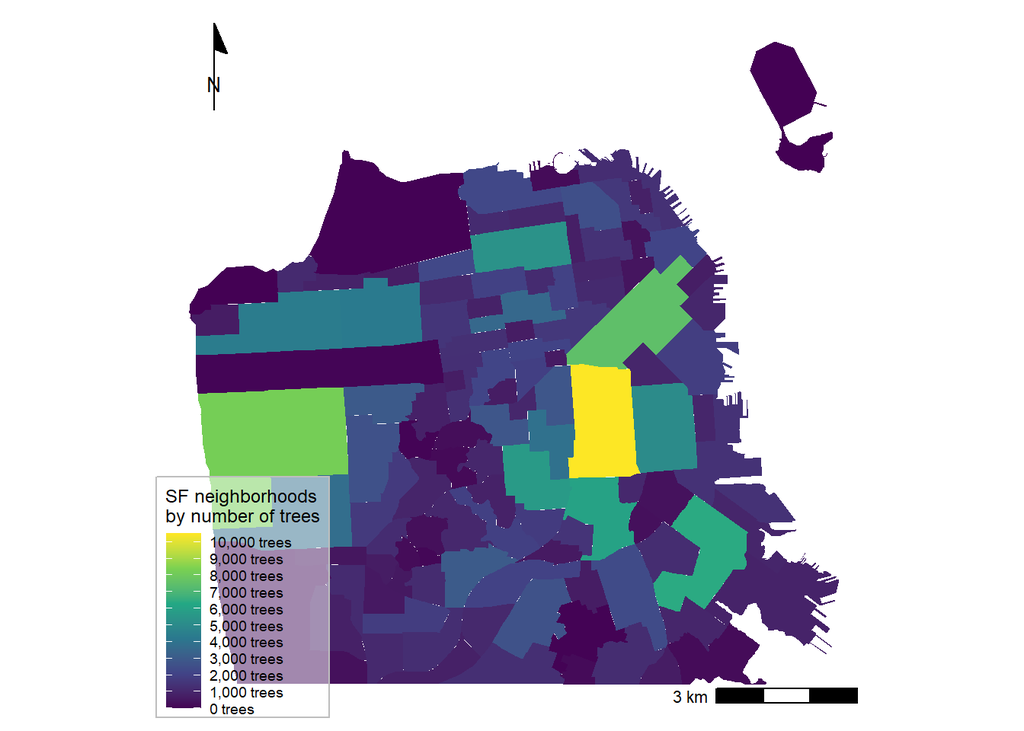

```r
#Counting urban trees within neighborhoods

nbhoods <- nbhoods %>%
  mutate(num_trees_inside = lengths(st_covers(nbhoods, trees_inside)))

ggplot(nbhoods) +
  geom_sf(color = NA,
          aes(fill = num_trees_inside)) +
  scale_fill_viridis_c(name = "SF neighborhoods\nby number of trees",
                       breaks = breaks <- seq(0, 10000, by = 1000),
                       labels = paste(prettyNum(breaks, big.mark = ","),
                                      "trees")) +
  annotation_scale(location = "br") +
  annotation_north_arrow(location = "tl",
                         style = north_arrow_minimal()) +
theme_map() +
  theme(legend.background = element_rect(fill = alpha("white", 0.5),
                                         color = "gray"))
```

**15) Average number of A points in each C polygon**

Average number of urban trees (A) in each SF Neighborhood (C)= 1644.744

```r
nbhoods <- nbhoods %>% drop_na(num_trees_inside)
average_n_trees <- mean(nbhoods$num_trees_inside)
average_n_trees
```

```
## [1] 1644.744
```

**Map 2:** **(19)The average density of A points in each C polygon**

The average density of Urban Trees [A] in each SF Neighborhood [C]= 2002.691 / sq.km

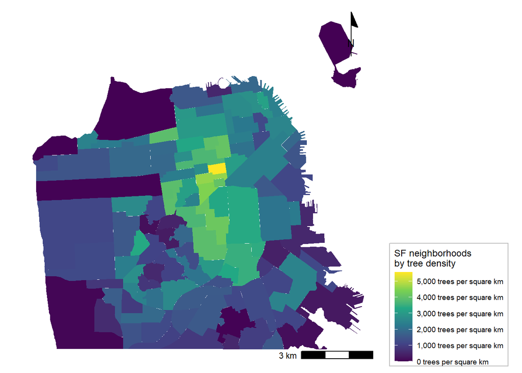

```r
# Density of urban trees in each neighborhood

nbhoods <- nbhoods %>%
  mutate(area = set_units(st_area(nbhoods), km^2)) %>%
  mutate(tree_dens = as.numeric(num_trees_inside / area))

ggplot(nbhoods) +
  geom_sf(color = NA,
          aes(fill = tree_dens)) +
    scale_fill_viridis_c(name =
                           "SF neighborhoods\nby tree density",
                       breaks = breaks <- seq(0, 10000, by = 1000),
                       labels = paste(prettyNum(breaks, big.mark = ","),
                                      "trees per square km")) +
  annotation_scale(location = "br") +
  annotation_north_arrow(location = "tr",
                         style = north_arrow_minimal()) +
theme_map() +
  theme(legend.position = "right",
    legend.background = element_rect(fill = alpha("white", 0.5),
                                         color = "gray"))
```

Calculating Average

```r
#Average
nbhoods <- nbhoods %>% drop_na(tree_dens)

mean_tree_density_nbhoods <- mean(nbhoods$tree_dens)

mean_tree_density_nbhoods
```

```
## [1] 2002.691
```

**Map 3:** **(7)The number and proportion of B points within C polygons**

The number and proportion of Bike Stations [B] within SF Neighborhoods [C].

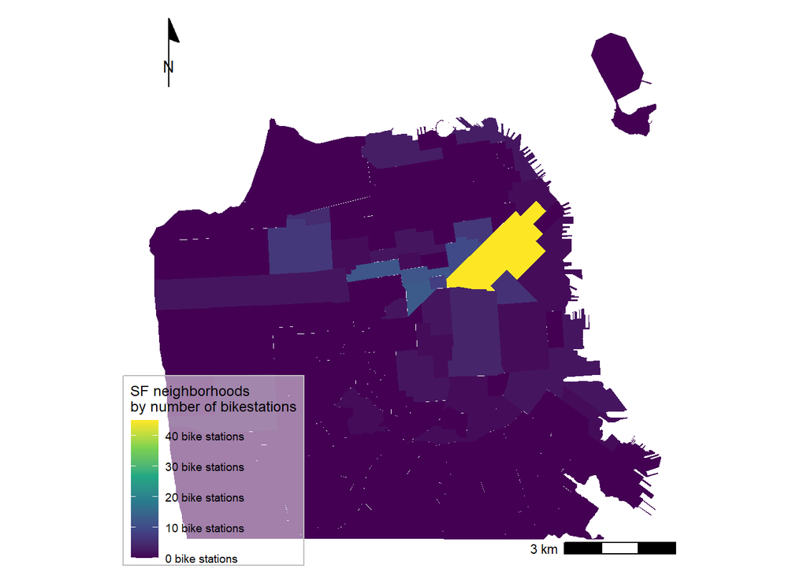

```r
#Counting bike stations within neighborhoods

nbhoods <- nbhoods %>%
  mutate(num_bikestations_inside = lengths(st_covers(nbhoods, bikenetwork)))

ggplot(nbhoods) +
  geom_sf(color = NA,
          aes(fill = num_bikestations_inside)) +
  scale_fill_viridis_c(name = "SF neighborhoods\nby number of bikestations",
                       breaks = breaks <- seq(0, 60, by = 10),
                       labels = paste(prettyNum(breaks, big.mark = ","),
                                      "bike stations")) +
  annotation_scale(location = "br") +
  annotation_north_arrow(location = "tl",
                         style = north_arrow_minimal()) +
theme_map() +
  theme(legend.background = element_rect(fill = alpha("white", 0.5),
                                         color = "gray"))
```

Average number of Bike Stations [B] in each SF Neighborhood [C]= 1.401.

```r
nbhoods <- nbhoods %>% drop_na(num_bikestations_inside)
average_n_bikestations <- mean(nbhoods$num_bikestations_inside)
average_n_bikestations
```

```
## [1] 1.401709
```

**Map 4:** **(21)The average density of B points in each C polygon**

The average density of Bike Station [B] in each SF Neighborhood [C]= 2.14 / sq.km

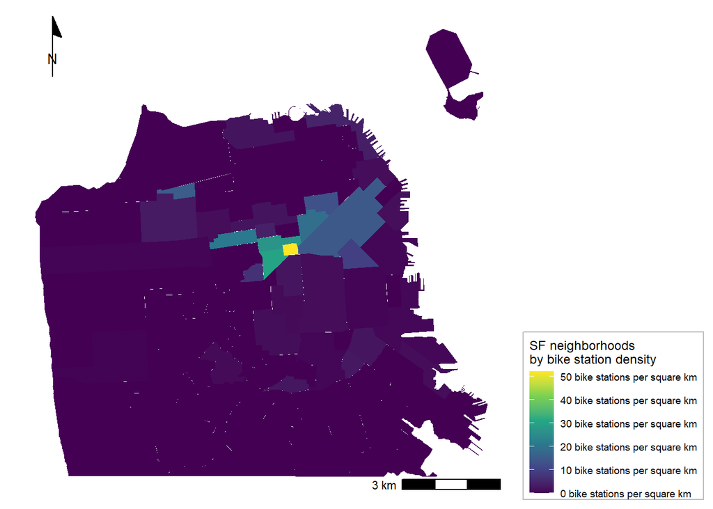

```r
# Density of bike station in each neighborhood

nbhoods <- nbhoods %>%
  mutate(area = set_units(st_area(nbhoods), km^2)) %>%
  mutate(bikestations_dens = as.numeric(num_bikestations_inside / area))

ggplot(nbhoods) +
  geom_sf(color = NA,
          aes(fill = bikestations_dens)) +
    scale_fill_viridis_c(name =
                           "SF neighborhoods\nby bike station density",
                       breaks = breaks <- seq(0, 60, by = 10),
                       labels = paste(prettyNum(breaks, big.mark = ","),
                                      "bike stations per square km")) +
  annotation_scale(location = "br") +
  annotation_north_arrow(location = "tl",
                         style = north_arrow_minimal()) +
theme_map() +
  theme(legend.position = "right",
    legend.background = element_rect(fill = alpha("white", 0.5),
                                         color = "gray"))
```

Calculating Average

```r
#Average
nbhoods <- nbhoods %>% drop_na(bikestations_dens)

mean_bikestation_density_nbhoods <- mean(nbhoods$bikestations_dens)

mean_bikestation_density_nbhoods
```

```
## [1] 2.142084
```

**Map [EXTRA]:** **(7b)The number and proportion of B2 points within C polygons**

The number and proportion of Green Roofs [B2] within SF Neighborhoods [C].

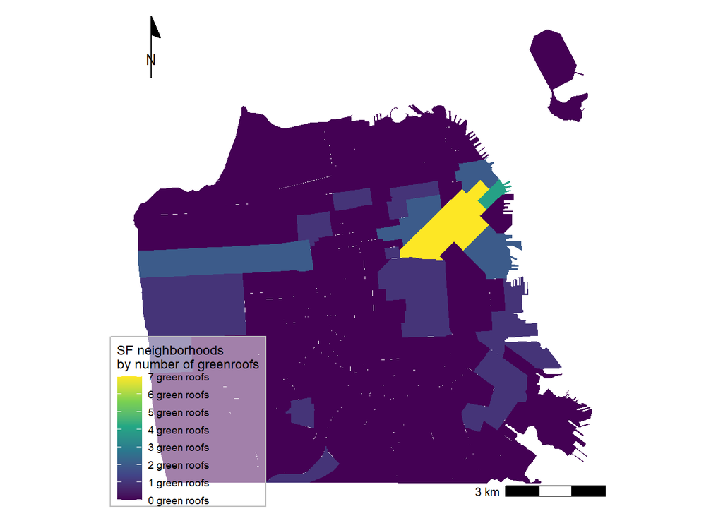

```r
#Counting green roofs within neighborhoods

nbhoods <- nbhoods %>%
  mutate(num_greenroofs_inside = lengths(st_covers(nbhoods, greenroofs)))

ggplot(nbhoods) +
  geom_sf(color = NA,
          aes(fill = num_greenroofs_inside)) +
  scale_fill_viridis_c(name = "SF neighborhoods\nby number of greenroofs",
                       breaks = breaks <- seq(0, 10, by = 1),
                       labels = paste(prettyNum(breaks, big.mark = ","),
                                      "green roofs")) +
  annotation_scale(location = "br") +
  annotation_north_arrow(location = "tl",
                         style = north_arrow_minimal()) +
theme_map() +
  theme(legend.background = element_rect(fill = alpha("white", 0.5),
                                         color = "gray"))
```

*15) Average number of B2 points in each C polygon*

Average number of green roofs [B2] in each SF Neighborhood [C]= 0.29

```r
nbhoods <- nbhoods %>% drop_na(num_greenroofs_inside)
average_n_greenroofs <- mean(nbhoods$num_greenroofs_inside)
average_n_greenroofs
```

```
## [1] 0.2991453
```

*Note: The map highlights the absolute number of Green roofs being distributed in the neighborhoods in San Francisco. This output highlights how the green-roofs are spatially concentrated in some neighborhoods and absent in others. This can help shed light on how resources are being concentrated in the San Francisco neighborhood and serve as a point of information directing the government on how to allocate resources to encourage adoption of green-roofs in neighborhoods that do not have green-roofs.*

**Map [EXTRA]:**

*(21b)The average density of B2 points in each C polygon*

The average density of Green Roofs [B2] in each SF Neighborhood [C]= 0.43 / sq.km

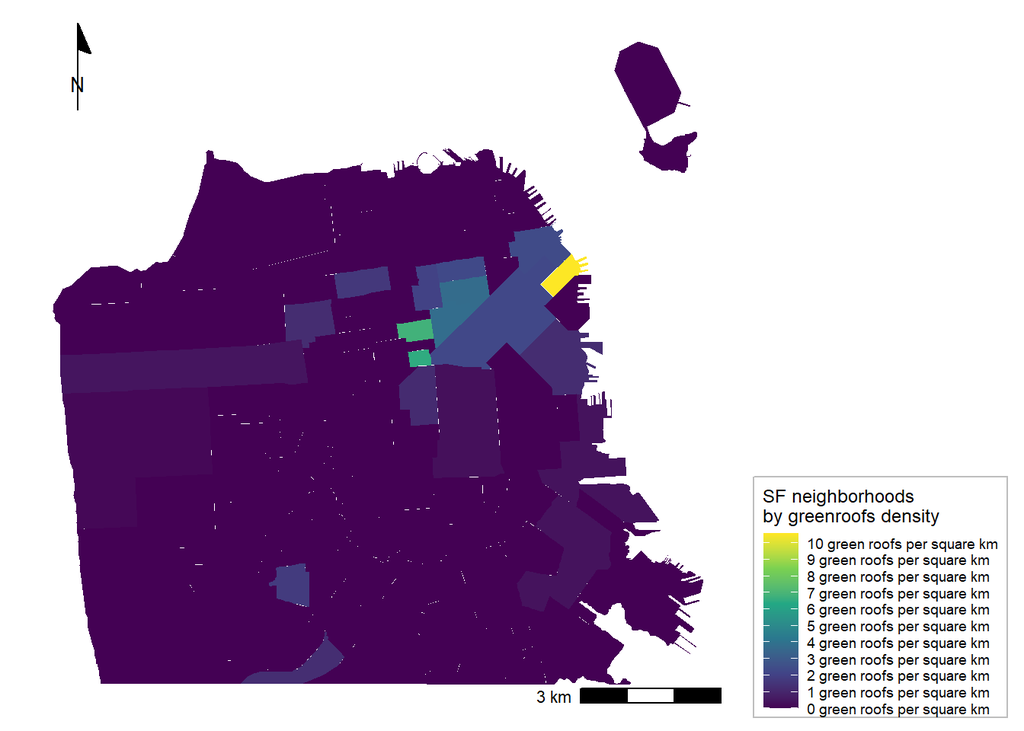

```r
# Density of green roofs in each neighborhood

nbhoods <- nbhoods %>%
  mutate(area = set_units(st_area(nbhoods), km^2)) %>%
  mutate(greenroofs_dens = as.numeric(num_greenroofs_inside / area))

ggplot(nbhoods) +
  geom_sf(color = NA,
          aes(fill = greenroofs_dens)) +
    scale_fill_viridis_c(name =
                           "SF neighborhoods\nby greenroofs density",
                       breaks = breaks <- seq(0, 10, by = 1),
                       labels = paste(prettyNum(breaks, big.mark = ","),
                                      "green roofs per square km")) +
  annotation_scale(location = "br") +
  annotation_north_arrow(location = "tl",
                         style = north_arrow_minimal()) +
theme_map() +
  theme(legend.position = "right",
    legend.background = element_rect(fill = alpha("white", 0.5),
                                         color = "gray"))
```

Calculating Average

```r
nbhoods <- nbhoods %>% drop_na(greenroofs_dens)

mean_greenroofs_density_nbhoods <- mean(nbhoods$greenroofs_dens)

mean_greenroofs_density_nbhoods
```

```
## [1] 0.43129
```

*Note: An interesting point to note is that density has a different impact on the map as opposed to comparing absolute data. This is highlighted though the change in color of the map where the smaller neighborhood becomes yellow compared to the larger neighborhood which was initially yellow when measuring absolutes (refer to graph above). These two maps together serve as a cautionary tale, to check whether the map illustrates max. green roofs in a certain neighborhood or because of size of that neighborhood effecting density.*

**Map 5:**

**(14)The number and proportion of C polygons that overlap with D polygons**

The number and proportion of Neighborhoods [C] that have Parks in them [D] = 45 Percentage = 38.46%

This map makes clear which neighborhoods lack open, green spaces.

```r
nbhoods <- nbhoods %>%
  mutate(num_parks_inside = lengths(st_overlaps(nbhoods, parks_inside))) %>%
  mutate(has_parks_inside = num_parks_inside > 0)

n_parks_inside_Nbhoods <- sum(nbhoods$has_parks_inside)

n_parks_inside_Nbhoods
```

```
## [1] 45
```

```r
pct_parks_inside_nbhoods <- n_parks_inside_Nbhoods / nrow(nbhoods)
pct_parks_inside_nbhoods
```

```
## [1] 0.3846154
```

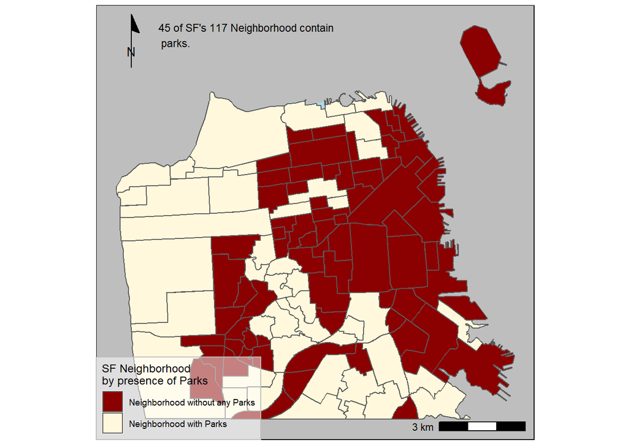

```r
left_side  <- st_bbox(parks_inside)$xmin
top_side <- st_bbox(parks_inside)$ymax

ggplot(parks_inside) +
  geom_sf(fill = "lightblue", color = NA) +
  geom_sf(data = nbhoods,
          aes(fill = has_parks_inside)) +
  scale_fill_manual(values = c("darkred", "cornsilk1"),
          name = "SF Neighborhood\nby presence of Parks",
          labels = c("Neighborhood without any Parks",
                     "Neighborhood with Parks")) +
  annotation_scale(location = "br") +
  annotation_north_arrow(location = "tl",
                         style = north_arrow_minimal()) +
  annotate(geom = "text", x = left_side + 4000,
           y = top_side + 6000,
           label = paste(n_parks_inside_Nbhoods ,
                         "of SF's",
                         length(nbhoods$name),
                         "Neighborhood contain\n",
                         "parks."),
           hjust = 0, vjust = 0, size = 3) +
  theme_map() +
  theme(panel.background = element_rect(fill = "gray"),
        legend.background = element_rect(fill = alpha("white", 0.5),
                                         color = "gray"))
```

**Map 6:** **(1) The number and proportion of A points within a specified distance of B points**

This map helps understand which of the bike stands are most shaded.

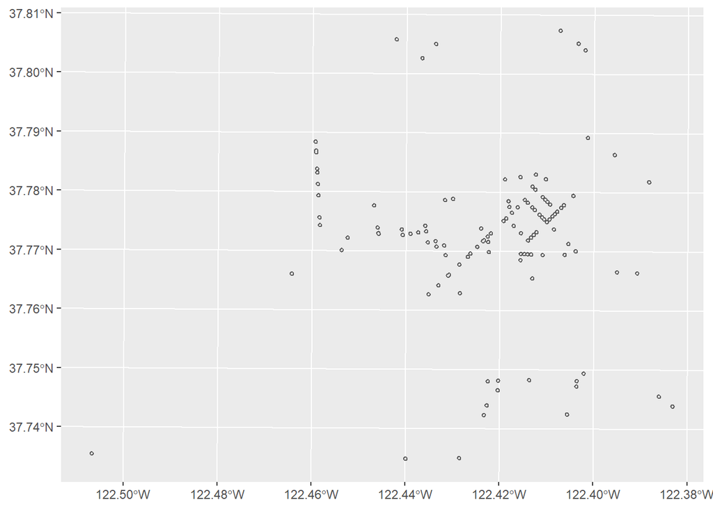

```r
bike_buffer <- st_buffer(bikenetwork, dist = 100) %>%
  st_union()

ggplot(bike_buffer) +
  geom_sf ()
```

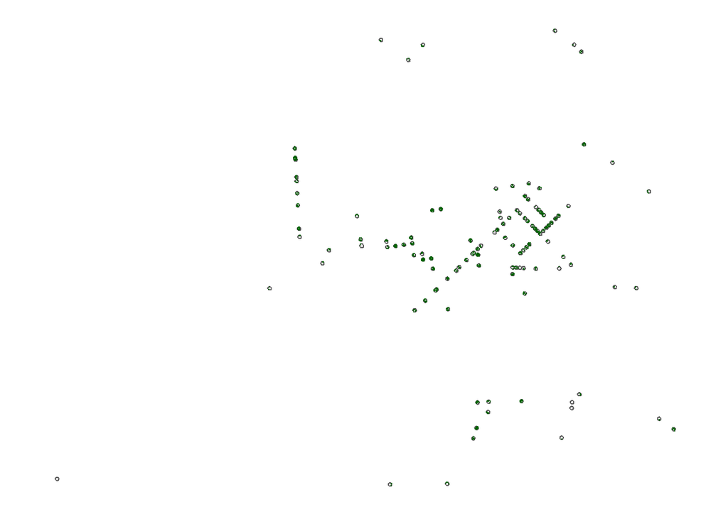

```r
#Subsetting
trees_inside_bike <- trees_inside[bike_buffer,]

ggplot(bike_buffer) +
  geom_sf() +
  geom_sf(data = trees_inside_bike,
          color = "darkgreen",
          size = 0.01) +
  theme_map()
```

```r
trees_inside <- trees_inside %>%
  st_join(trees_inside_bike)%>%
  mutate(by_bike = !is.na(XCoord.y))

n_bike_trees_inside <- sum(trees_inside$by_bike)
n_bike_trees_inside
```

```
## [1] 4658
```

```r
pct_bike_trees_inside <- n_bike_trees_inside/nrow(trees_inside)
pct_bike_trees_inside
```

```
## [1] 0.02383328
```

#Plotting Data

[figure not shown]

```r
left_side  <- st_bbox(trees_inside)$xmin
top_side <- st_bbox(trees_inside)$ymax

ggplot(nbhoods) +
  geom_sf(fill = NA , color = 'black') +
  geom_sf(data = trees_inside, size = 0.02,
          aes(color = by_bike)) +
  scale_color_manual(values = c("lightgreen", "darkgreen"),
          name = "SF Trees\nby distance to a bike station",
          labels = c("No Tree within 100 m",
                     "Tree within 100 m")) +
  annotation_scale(location = "br") +
  annotation_north_arrow(location = "tr",
                         style = north_arrow_minimal()) +
  annotate(geom = "text", x = left_side,
           y = top_side + 5000,
           label = paste("Of the 50000 ",
                         " trees in SF ",
                          prettyNum(n_bike_trees_inside, big.mark = ","),
                         " (",
                         prettyNum(100*pct_bike_trees_inside, digits = 0),
                         "%) are within 100\nmeters of a parking meter.",
                         sep = ""),
           hjust = 0, vjust = 0, size = 3) +
  theme_map() +
  theme(panel.background = element_rect(fill = "cornsilk1"),
        legend.background = element_rect(fill = alpha("white", 0.5),
                                         color = "gray"))
```

**Team Contribution Statement**

As a team, we each were eager to learn the different components of the exercise, due to which each one of us undertook the task of creating as many maps as possible. We decided on the city and data set early on as well as what we were hoping to explore and then split up. On the last day, we selected 6 maps that best represent our team.

According to us, everyone contributed equally due to which we would like to award 10 points to each member.